# Lending Club Case Study

## Higher the *'dti'* higher the chances of loan being *'Charged Off'*

```python
loan.delinq_2yrs.value_counts(normalize=True)
```

```
0     0.891594
1     0.083100
2     0.017361
3     0.005344
4     0.001499
5     0.000594
6     0.000283
7     0.000113
8     0.000057
11    0.000028
9     0.000028
Name: delinq_2yrs, dtype: float64
```

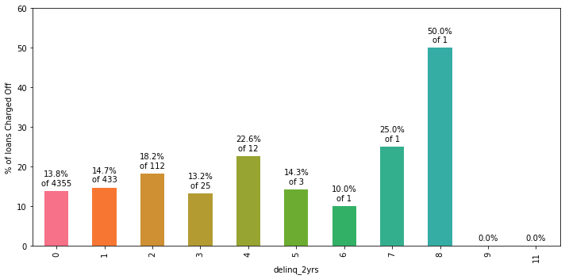

```python
plt.figure(figsize=(10,5))
plotLoanStatus(loan, 'delinq_2yrs')
```

## The number of 30+ days past-due incidences of delinquency in the borrower's credit file for the past 2 years values ranges between 0 and 11.

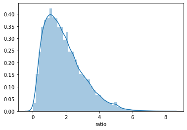

```python
#ratio of loan vs salary
loan['ratio'] = loan['loan_amnt'] * 10 / loan['annual_inc']
sns.distplot(loan['ratio'])
```

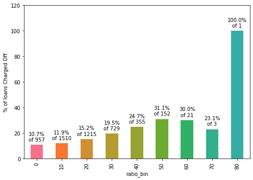

```python
loan['ratio_bin'] = (loan['ratio'].astype(int)) * 10
plt.figure(figsize=(7,5))
plotLoanStatus(loan, 'ratio_bin')
```

### Loan amounts of *30%* of annual income or higher see a high rate of *'default'*.

```python
loan.earliest_cr_line_year.value_counts(normalize=True).head()
```

```
2000    0.083326
1999    0.076201
1998    0.072638
2001    0.065259
1997    0.062403
Name: earliest_cr_line_year, dtype: float64
```

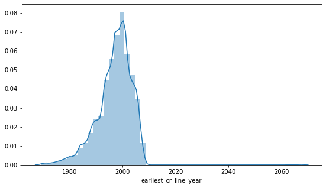

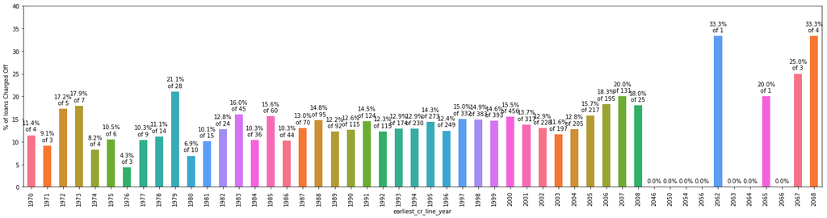

```python
plt.figure(figsize=(20,5))
plt.subplot(1, 2, 1)
sns.distplot(loan['earliest_cr_line_year'])


plt.figure(figsize=(40,10))
plt.subplot(2, 2, 1)
plotLoanStatus(loan.loc[loan['earliest_cr_line_year'] > 1969], 'earliest_cr_line_year')
plt.show()
```

### 8% of the loan applicants have 2000 as the year of earliest credit line.

### Newer borrowers are defauling more often. This is possibly related to the 2008 subprime crisis.

```python
loan.inq_last_6mths.value_counts(normalize=True)
```

```
0    0.485848
1    0.276359
2    0.147256
3    0.076427
4    0.007917
5    0.003478
6    0.001527
7    0.000877
8    0.000311
Name: inq_last_6mths, dtype: float64
```

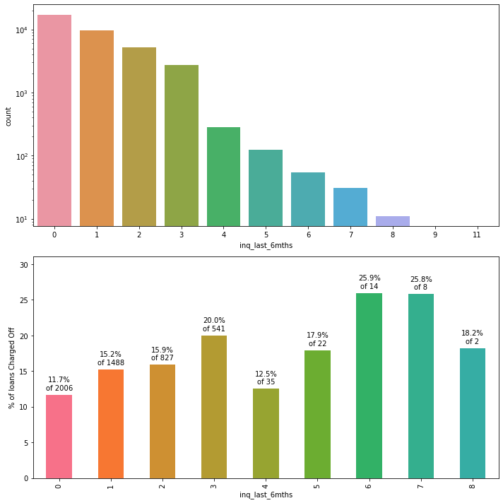

```python
plt.figure(figsize=(10,10))
plt.subplot(2, 1, 1)
c=sns.countplot(loan['inq_last_6mths'], order=sorted(loan.delinq_2yrs.unique()))
c.set_yscale('log')

plt.subplot(2, 1, 2)
plotLoanStatus(loan, 'inq_last_6mths')
plt.show()
```

### 48.5% of the borrowers do not make any inquiry

### Those with more than 2 inquiries default at higher rates for *'defualt'*.

### This is probably correlated to having more loans and can be ignored.

```python
loan.pub_rec.value_counts(normalize=True)
```

```
0    0.947663
1    0.050838
2    0.001244
3    0.000198
4    0.000057
Name: pub_rec, dtype: float64
```

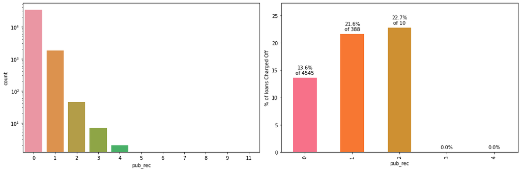

```python
plt.figure(figsize=(15,5))
plt.subplot(1, 2, 1)
c=sns.countplot(loan['pub_rec'], order=sorted(loan.delinq_2yrs.unique()))
c.set_yscale('log')

plt.subplot(1, 2, 2)
plotLoanStatus(loan, 'pub_rec')
plt.show()
```

### 94% have no Public derogatory records. 5% have 1 derogatory record.

### Having even 1 derogatory record increases the chances of Charge Off significantly.

```python
loan.last_pymnt_d.value_counts().head()
```

```
2013-03-01    967
2014-12-01    875
2013-05-01    856
2013-02-01    816
2012-03-01    799
Name: last_pymnt_d, dtype: int64
```

```python
loan['last_pymnt_d_month']= loan['last_pymnt_d'].dt.month
loan['last_pymnt_d_year']= loan['last_pymnt_d'].dt.year
```

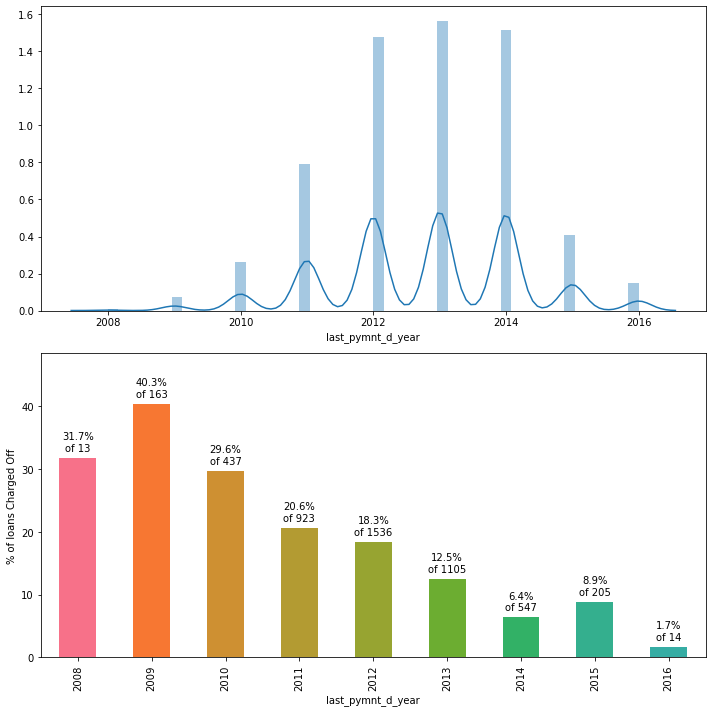

```python
plt.figure(figsize=(10,10))
plt.subplot(2, 1, 1)
#sns.countplot(master_loan['earliest_cr_line_year'], order=sorted(master_loan.issue_d_year.unique()))
sns.distplot(loan['last_pymnt_d_year'])
#plt.subplot(1, 2, 2)
#sns.countplot(master_loan['earliest_cr_line_month'], order=sorted(master_loan.issue_d_month.unique()))
#plt.show()

plt.subplot(2, 1, 2)
plotLoanStatus(loan, 'last_pymnt_d_year')
plt.show()
```

### Overall, around 75% of the last payment dates are during 2012-2014 period.

### 40% of loans with a last payment date of 2009 are Charged Off. This is due to the 2008 subprime crisis.

### This variable does not affect analysis and will be ignored.

# Finally,

## 1. Approx 14% of loan is defaulted.

## 2. Lending Club only recovers 57% of the loan amount when loans are defaulted. On fully paid up loans, the company makes 17% profit.

## 3. Most loans are high quality, with a grade of A or B and Lower grades have higher incidence of defaults on loans. The grading system helps in analysis.

## 4. Maximum number of loans are for debt consolidation, followed by credit card

## 5. Lending Club charges higher interest rates as the grade of loan becomes worse.

## 6. More than a quarter of loans taken for the purpose of running a small business see defaults.

## 7. Loan default decreases with higher annual income.

## 8. Loan amounts of 30% of annual income or higher see a high rate of default.